# ROC And AUC Example

Yalin Yang

2023-10-30

Material comes from : https://github.com/StatQuest/roc_and_auc_demo/blob/master/roc_and_auc_demo.R

## Load helper library

```r
library(pROC) # install with install.packages("pROC")
library(randomForest) # install with install.packages("randomForest")
```

## Generate weight and obesity datasets

```r
set.seed(420) # this will make my results match yours
num.samples <- 100
## genereate 100 values from a normal distribution with
## mean 172 and standard deviation 29, then sort them
weight <- sort(rnorm(n=num.samples, mean=172, sd=29))

## Now we will decide if a sample is obese or not.
## NOTE: This method for classifying a sample as obese or not
## was made up just for this example.
## rank(weight) returns 1 for the lightest, 2 for the second lightest, ...
##              ... and it returns 100 for the heaviest.
```

So what we do is generate a random number between 0 and 1. Then we see if that number is less than $rank/100$. So, for the lightest sample, $rank = 1$. This sample will be classified “obese” if we get a random number less than $1/100$. For the second lightest sample, $rank = 2$, we get another random number between 0 and 1 and classify this sample “obese” if that random number is < $2/100$. We repeat that process for all 100 samples.

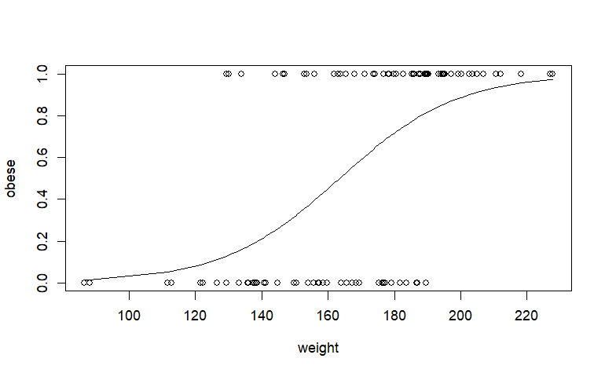

```r
obese <- ifelse(test=(runif(n=num.samples) < (rank(weight)/num.samples)),
  yes=1, no=0)

## plot the data
plot(x=weight, y=obese)

## fit a logistic regression to the data...
glm.fit=glm(obese ~ weight, family=binomial)
lines(weight, glm.fit$fitted.values)
```

## draw ROC and AUC using pROC

NOTE: By default, the graphs come out looking terrible The problem is that ROC graphs should be square, since the x and y axes both go from 0 to 1. However, the window in which I draw them isn’t square so extra white space is added to pad the sides.

```
Call:
roc.default(response = obese, predictor = glm.fit$fitted.values,     plot = TRUE)

Data: glm.fit$fitted.values in 45 controls (obese 0) < 55 cases (obese 1).
Area under the curve: 0.8291
```

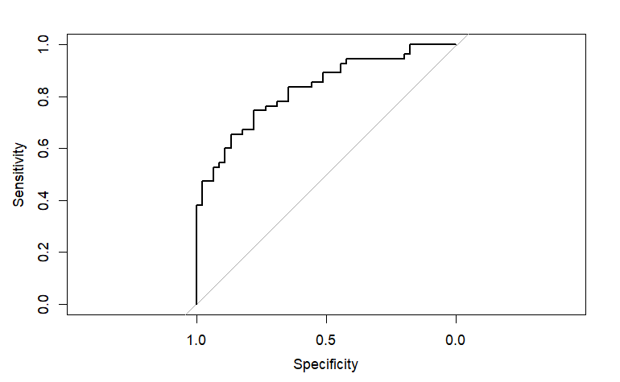

```r
roc(obese, glm.fit$fitted.values, plot=TRUE)
```

Now let’s configure R so that it prints the graph as a square.

```
Call:
roc.default(response = obese, predictor = glm.fit$fitted.values,     plot = TRUE)

Data: glm.fit$fitted.values in 45 controls (obese 0) < 55 cases (obese 1).
Area under the curve: 0.8291
```

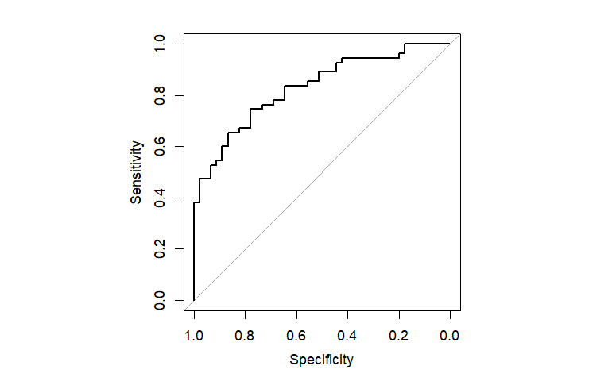

```r
par(pty = "s") ## pty sets the aspect ratio of the plot region. Two options:
##                "s" - creates a square plotting region
##                "m" - (the default) creates a maximal plotting region
roc(obese, glm.fit$fitted.values, plot=TRUE)
```

NOTE: By default, roc() uses specificity on the x-axis and the values range from 1 to 0. This makes the graph look like what we would expect, but the x-axis itself might induce a headache. To use **1-specificity (i.e. the False Positive Rate)** on the x-axis, set `"legacy.axes" to TRUE`.

```
Call:
roc.default(response = obese, predictor = glm.fit$fitted.values,     plot = TRUE, legacy.axes = TRUE)

Data: glm.fit$fitted.values in 45 controls (obese 0) < 55 cases (obese 1).
Area under the curve: 0.8291
```

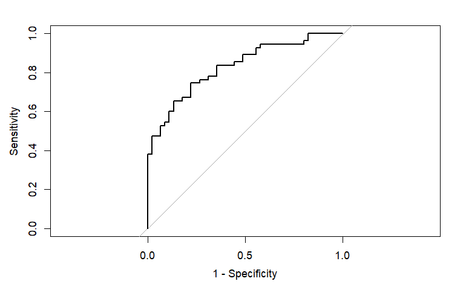

```r
roc(obese, glm.fit$fitted.values, plot=TRUE, legacy.axes=TRUE)
```

If you want to rename the x and y axes…

```
Call:
roc.default(response = obese, predictor = glm.fit$fitted.values,     percent = TRUE, plot = TRUE, legacy.axes = TRUE, xlab = "False Positive Percentage",     ylab = "True Postive Percentage")

Data: glm.fit$fitted.values in 45 controls (obese 0) < 55 cases (obese 1).
Area under the curve: 82.91%
```

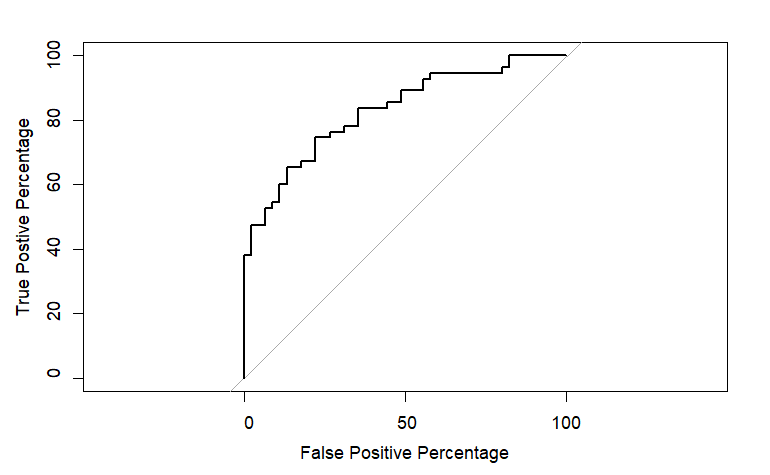

```r
roc(obese, glm.fit$fitted.values, plot=TRUE, legacy.axes=TRUE, percent=TRUE, xlab="False Positive Percentage", ylab="True Postive Percentage")
```

We can also change the color of the ROC line, and make it wider…

```
Call:
roc.default(response = obese, predictor = glm.fit$fitted.values,     percent = TRUE, plot = TRUE, legacy.axes = TRUE, xlab = "False Positive Percentage",     ylab = "True Postive Percentage", col = "#377eb8", lwd = 4)

Data: glm.fit$fitted.values in 45 controls (obese 0) < 55 cases (obese 1).
Area under the curve: 82.91%
```

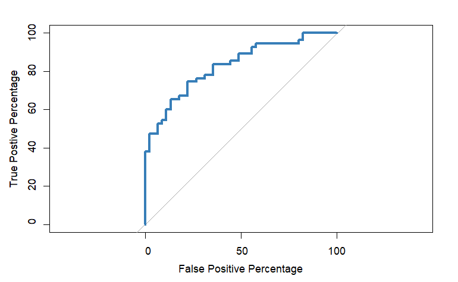

```r
roc(obese, glm.fit$fitted.values, plot=TRUE, legacy.axes=TRUE, percent=TRUE, xlab="False Positive Percentage", ylab="True Postive Percentage", col="#377eb8", lwd=4)
```